# Vahan : Take-Home task

```python
#mapping the source dict created to the source column.
vahan_df["source"] = vahan_df.source.map(source_ref)
```

[figure not shown]

```python
sns.countplot('source',data=vahan_df)
plt.show()
```

As you can notice 'word of mouth' is the key, with large number of leads generated through refferrals, follwed by API related leads.

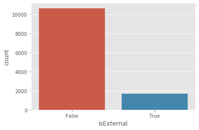

```python
sns.countplot('isExternal',data=vahan_df)
plt.show()
```

So here i wanted to check how the leads were accquired, and seems that 85% of the leads came from the job assistance.

```python
#the source input had many unclean or unstructured information. Inorder to make it understandable i developed classes based on the wide range of text and created a dict to map them in the data.
status_ref = {"CNP/Switched Off/Not Reachable":"RNR","Wrong Number/Number Not Valid":"Not-Interested","Very Interested":"Interested","RNR":"RNR","Not Interested - Disconnected the Call":"Not-Interested","Not Interested - Got Other Jobs":"Not-Interested","Not Interested - Not Applied":"Not-Interested","Not Interested":"Not-Interested","Interested":"Interested","Not Applied":"RNR","Not Interested - Wrong Number":"Not-Interested","Don't Meet Requirements":"RNR","Other Reasons":"RNR","Switched Off/Not Reachable":"RNR","Disconnected the Call":"RNR","Switched Off/Not Reachable/No Incoming":"RNR","Not Interested - Location Issue":"Not-Interested","Want Non-Delivery Jobs":"RNR","Not Interested - Applied by Mistake":"Not-Interested","Not Interested - Not Sure":"Not-Interested","Not Interested - Others":"Not-Interested","Not Sure":"RNR","Joined":"Not-Interested","Got Other Jobs":"Not-Interested","Location Issue":"RNR","Language Barrier":"RNR","Not Interested - Want Non-Delivery Jobs":"Not-Interested","Applied for Someone Else":"RNR","Applied by Mistake":"Not-Interested","Not sure":"RNR","Not Interested - Want Jobs in Other Category":"Not-Interested","Number Not Valid/Number Does Not Exist":"Not-Interested","Call Back":"RNR","Not Interested - Want Jobs in Other Company (but same category)":"Not-Interested","Not Interested - Call Back":"Not-Interested","Want Other Delivery Jobs":"RNR","Disconnected the call":"RNR","Not Interested - Want Other Delivery Jobs":"Not-Interested","Not Interested but Referred Someone":"Not-Interested","Interested but CNP on Follow-up":"Interested","Interested and Referred Someone":"Interested","Interested but in village":"Interested","Interested but RNR on Follow-up":"Interested","Not interested":"Not-Interested","Applied by mistake":"Not-Interested","Location issue":"RNR","CNP/Switched off/Not Reachable":"RNR","Switched Off/Not Reachable/No Incoming Up":"RNR"}
```

```python
vahan_df["status"] = vahan_df.status.map(status_ref) #mapping the status with the dict created.
```

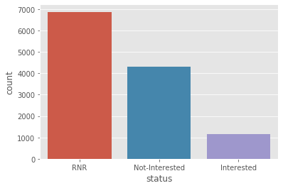

```python
sns.countplot('status',data=vahan_df)
plt.show()
```

Most of the calls not valid & only around 10% of the leads were converted to Interest, which indicated the effectivness.

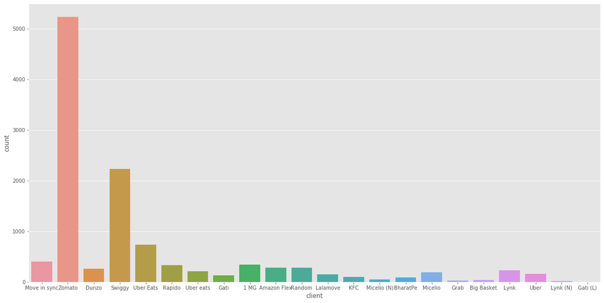

```python
plt.figure(figsize=(20, 10))
sns.countplot('client',data=vahan_df)
plt.show()
```

Largely clients with requirement of delievery are leveraging on Vahan's service model. Can look to create awarness on other delievery or door to door service modules, to increase the service base.

```python
vahan_df = pd.merge(leads, lead_calls, left_on = 'leadId', right_on = 'leadId', how = 'inner') # running this to remove CalledAt indexing.
```

```python
vahan_df['calledAt'] = vahan_df['calledAt'].astype(str)
vahan_df.loc[vahan_df['calledAt'] == "2016-08-26 14:30:00+00:00", 'calledAt'] = "2019-08-26 14:30:00+00:00"
vahan_df.loc[vahan_df['calledAt'] == "2020-06-01 10:30:00+00:00", 'calledAt'] = "2019-06-01 10:30:00+00:00"
vahan_df.loc[vahan_df['calledAt'] == "2020-05-01 10:30:00+00:00", 'calledAt'] = "2019-05-01 10:30:00+00:00"
vahan_df.loc[vahan_df['calledAt'] == "2020-04-01 10:30:00+00:00", 'calledAt'] = "2019-04-01 10:30:00+00:00"
vahan_df.loc[vahan_df['calledAt'] == "2020-08-30 10:30:00+00:00", 'calledAt'] = "2019-08-30 10:30:00+00:00"
vahan_df.loc[vahan_df['calledAt'] == "2020-08-30 11:30:00+00:00", 'calledAt'] = "2019-08-30 11:30:00+00:00"
```

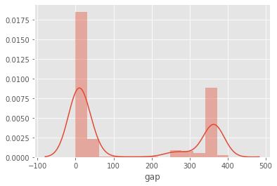

```python
#Checking the gap between leads received and call made, to further deep dive on efficiency.
vahan_df[["calledAt", "receivedAt"]] = vahan_df[["calledAt", "receivedAt"]].apply(pd.to_datetime)
vahan_df['gap'] = abs((vahan_df['calledAt'] - vahan_df['receivedAt']).dt.days)
sns.distplot(vahan_df['gap']);
```

Majority of the calls were done almost immediately, few of the calls were done almost a year later.

```python
vahan_df["status"] = vahan_df.status.map(status_ref)# recalling the maping of status since we reloaded the vahan data frame.
```

```python
#Measuring Efficiency with respect to the states.Here i have created a formula with Interest or conversion percentage with the overall calls made for each state.
status_state = vahan_df[['state', 'status','id']].groupby(['state','status']).count().reset_index()
status_state = status_state.pivot(index='state', columns='status', values='id').reset_index()
status_state = status_state.fillna(0)
status_state['Net_calls'] = status_state['Interested']+status_state['Not-Interested']+status_state['RNR']
status_state['Converting_Efficiency'] = status_state['Interested']*100/status_state['Net_calls']
status_state.head()
```

| status | state | Interested | Not-Interested | RNR | Net_calls | Converting_Efficiency |
| --- | --- | --- | --- | --- | --- | --- |
| 0 | Andhra Pradesh | 2.0 | 20.0 | 25.0 | 47.0 | 4.255319 |
| 1 | Assam | 0.0 | 4.0 | 6.0 | 10.0 | 0.000000 |
| 2 | Bihar | 12.0 | 11.0 | 12.0 | 35.0 | 34.285714 |
| 3 | Delhi-NCR | 14.0 | 18.0 | 30.0 | 62.0 | 22.580645 |
| 4 | Gujarat | 3.0 | 3.0 | 0.0 | 6.0 | 50.000000 |

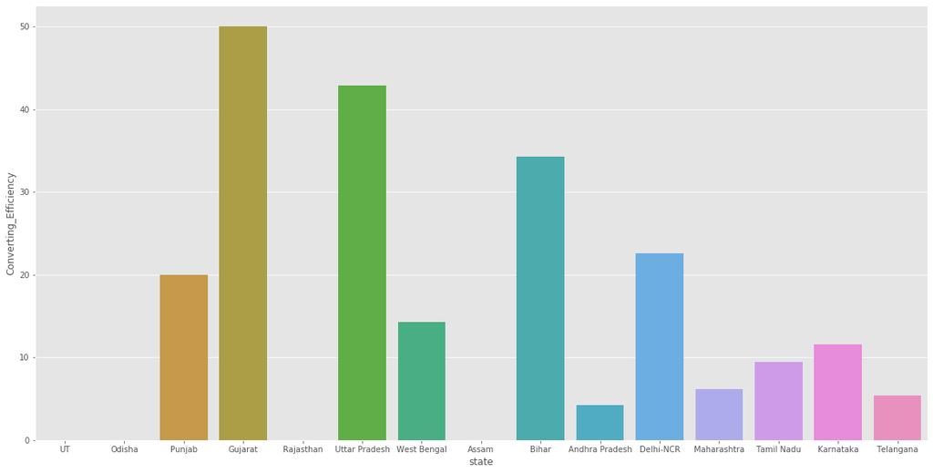

```python
plt.figure(figsize=(20, 10))
ax = sns.barplot(x="state", y="Converting_Efficiency", data=status_state.sort_values("Net_calls", ascending=True))
```

It is interesting to notice that despite Telangana, Karnatake, Tamil Nadu have more frequency of Calls. States like Gujarat, Delhi,Punjab, UP & Bihar have the most efficient conversions. I think Tele callers must be channelized further to target such states to create a larger service base.

```python
#Measuring Efficiency with respect to the Clients .Here i have created a formula with Interest or conversion percentage with the overall calls made for each Client.
client_status = vahan_df[['client', 'status','id']].groupby(['client','status']).count().reset_index()
client_status = client_status.pivot(index='client', columns='status', values='id').reset_index()
client_status = client_status.fillna(0)
client_status['Net_calls'] = client_status['Interested']+client_status['Not-Interested']+client_status['RNR']
client_status['Converting_Efficiency'] = client_status['Interested']*100/client_status['Net_calls']
client_status.head()
```

| status | client | Interested | Not-Interested | RNR | Net_calls | Converting_Efficiency |
| --- | --- | --- | --- | --- | --- | --- |
| 0 | 1 MG | 26.0 | 89.0 | 222.0 | 337.0 | 7.715134 |
| 1 | Amazon Flex | 38.0 | 97.0 | 142.0 | 277.0 | 13.718412 |
| 2 | BharatPe | 0.0 | 4.0 | 8.0 | 12.0 | 0.000000 |
| 3 | Big Basket | 7.0 | 8.0 | 21.0 | 36.0 | 19.444444 |
| 4 | Dunzo | 31.0 | 99.0 | 124.0 | 254.0 | 12.204724 |

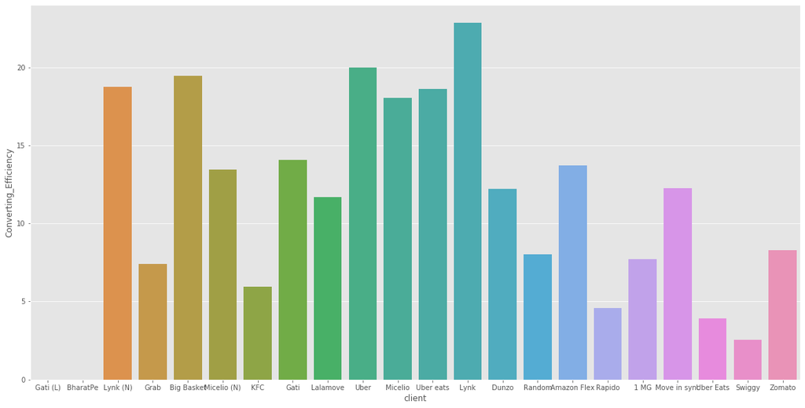

```python
plt.figure(figsize=(20, 10))
ax = sns.barplot(x="client", y="Converting_Efficiency", data=client_status.sort_values("Net_calls", ascending=True))
```

Again here we had seen most of the calls were made to food delivery clients like Zomato & Swiggy.But as we had seen statewise the conversions were high with states like Gujarat, UP, Bihar, Delhi & Punjab. Conversions is best in Lynk which is truck rental firm. Vahan needs to target truckers to gain more efficiency.

```python
TeleCaller_status = vahan_df[['TeleCallerName', 'status','id']].groupby(['TeleCallerName','status']).count().reset_index()
TeleCaller_status = TeleCaller_status.pivot(index='TeleCallerName', columns='status', values='id').reset_index()
TeleCaller_status = TeleCaller_status.fillna(0)
TeleCaller_status['Net_calls'] = TeleCaller_status['Interested']+TeleCaller_status['Not-Interested']+TeleCaller_status['RNR']
TeleCaller_status['Converting_Efficiency'] = TeleCaller_status['Interested']*100/TeleCaller_status['Net_calls']
TeleCaller_status.head()
```

| status | TeleCallerName | Interested | Not-Interested | RNR | Net_calls | Converting_Efficiency |
| --- | --- | --- | --- | --- | --- | --- |
| 0 | Amila | 243 | 1094 | 1191 | 2528 | 9.612342 |
| 1 | Rakshith | 16 | 11 | 13 | 40 | 40.000000 |
| 2 | Sheeba | 663 | 2851 | 4921 | 8435 | 7.860107 |

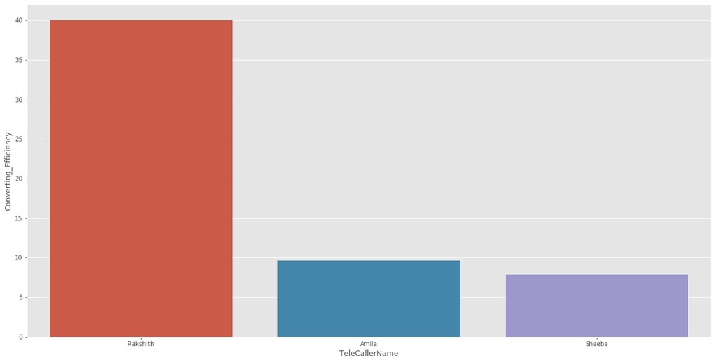

```python
plt.figure(figsize=(20, 10))
ax = sns.barplot(x="TeleCallerName", y="Converting_Efficiency", data=TeleCaller_status.sort_values("Net_calls", ascending=True))
```

Despite Sheeba making the most number of calls by a large margin, we can see that Rakshith conversions are better. This would largely be due to the low volumes leading to higher conversion ratio & vice-versa for Sheeba.

```python
source_status = vahan_df[['source', 'status','id']].groupby(['source','status']).count().reset_index()
source_status = source_status.pivot(index='source', columns='status', values='id').reset_index()
source_status = source_status.fillna(0)
source_status['Net_calls'] = source_status['Interested']+source_status['Not-Interested']+source_status['RNR']
source_status['Converting_Efficiency'] = source_status['Interested']*100/source_status['Net_calls']
source_status.head()
```

| status | source | Interested | Not-Interested | RNR | Net_calls | Converting_Efficiency |
| --- | --- | --- | --- | --- | --- | --- |
| 0 | API | 331 | 842 | 1316 | 2489 | 13.298513 |
| 1 | Facebook | 89 | 315 | 603 | 1007 | 8.838133 |
| 2 | Others | 53 | 284 | 235 | 572 | 9.265734 |
| 3 | Referrals | 289 | 2247 | 3047 | 5583 | 5.176428 |
| 4 | WhatsApp | 159 | 267 | 923 | 1349 | 11.786509 |

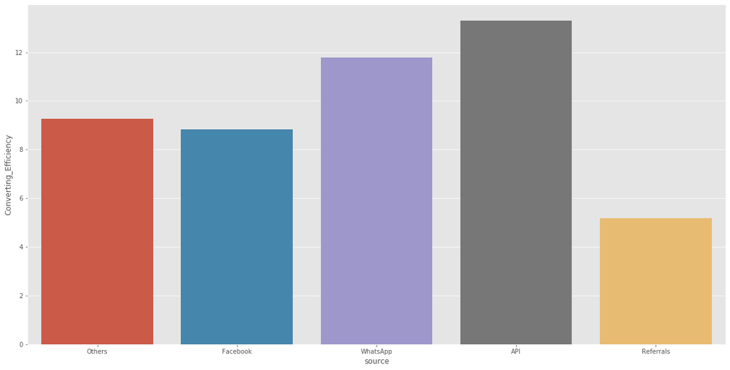

```python
plt.figure(figsize=(20, 10))
ax = sns.barplot(x="source", y="Converting_Efficiency", data=source_status.sort_values("Net_calls", ascending=True))
```

APIs have a better conversion rates, followed by WhatsApp and least are the referrals. It was also observed in the higher values give lower ratio of conversions.

```python
isexternal_status = vahan_df[['isExternal', 'status','id']].groupby(['isExternal','status']).count().reset_index()
isexternal_status = isexternal_status.pivot(index='isExternal', columns='status', values='id').reset_index()
isexternal_status = isexternal_status.fillna(0)
isexternal_status['Net_calls'] = isexternal_status['Interested']+isexternal_status['Not-Interested']+isexternal_status['RNR']
isexternal_status['Converting_Efficiency'] = isexternal_status['Interested']*100/isexternal_status['Net_calls']
isexternal_status.head()
```

| status | isExternal | Interested | Not-Interested | RNR | Net_calls | Converting_Efficiency |
| --- | --- | --- | --- | --- | --- | --- |
| 0 | False | 777 | 3184 | 5345 | 9306 | 8.349452 |
| 1 | True | 145 | 772 | 780 | 1697 | 8.544490 |

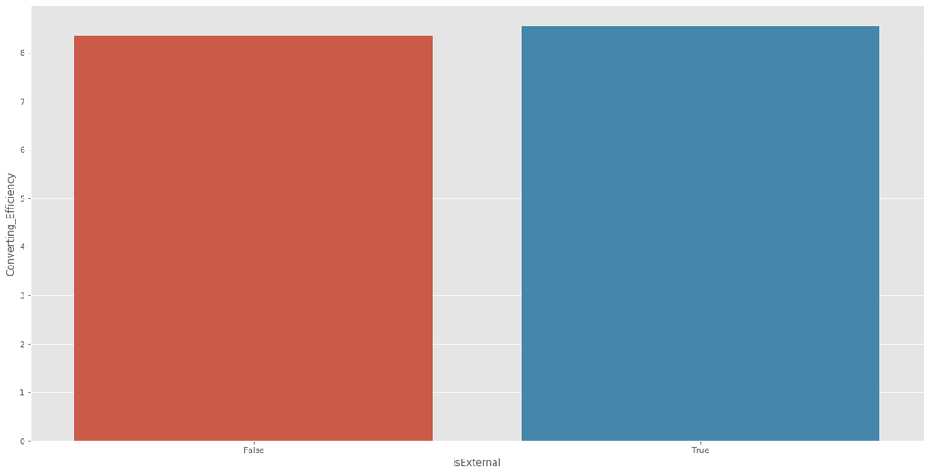

```python
plt.figure(figsize=(20, 10))
ax = sns.barplot(x="isExternal", y="Converting_Efficiency", data=isexternal_status.sort_values("Net_calls", ascending=True))
```